# Intro to Embedded Device Exploitation: Shellcode 0

# Exploitation

## Buffer Overflow

A buffer overflow is a common vulnerability that occurs when user input is not properly checked.

Imagine a programmer had a password field expecting 4-8 characters so they made the buffer 8 bytes. If they don't write code to handle receiving more than 8 bytes then they could suffer a buffer overflow when someone enters "PASSWORD12"

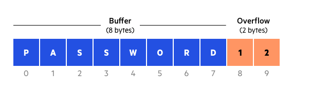

Doesn't seem like a huge deal, but let's look at how functions work

## Stack Frames

The stack has been in several of the images so far. If you are unfamiliar with the stack, go take a look at the memory sections for a quick reference. *Notice it starts at the highest part of user memory and decreases the address as it grows*

The **stack** is used as short term memory (but not as short term as the registers). It is used to save local/temporary variables and is used to save the state of the registers in function calls.

Think of calling `print("Hello World")`. In the print call (main) it will need to make a call to `strlen()` to get the length of the string to know how much to print. Before the `strlen()` call, the registers being used by `print()` will be saved on the stack so the program can use them during `strlen()`. After it finishes running `strlen()`, the values will be popped off the stack or restored so that `print()` can continue like nothing happened.

Look below, entry is where the file/program starts then main() is the block with the `print("Hello World")` call and f1 is the `strlen()` call. Each function has a **stack frame**, with its local variables, saved registers and the **return address** for when it finishes executing. Pointers (Ptr) are addresses so the computer knows where to find things.

In this image, the high numbers are at the top with 0 at the bottom, and the stack "grows down" towards the rest of the memory. It can be confusing, but each new variable is added at a lower address than the last.

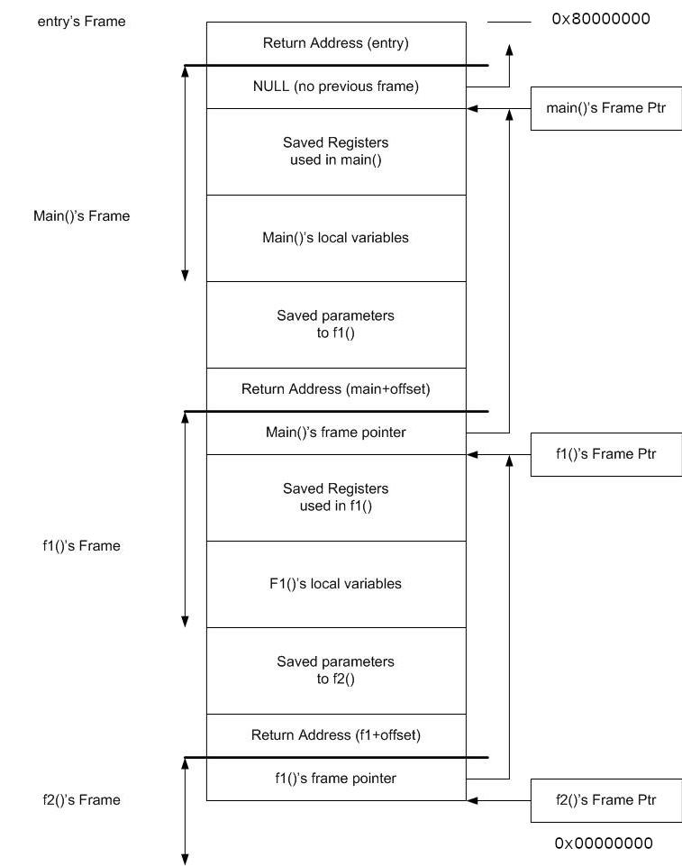

In another example, let's say a programmer assumes no one is going to need more than 20 characters to input their age, so they may make a buffer, or set aside a section of memory, for 20 characters.

If they do not write code to specifically check if the input is longer, and handle / discard it, then a malicious user could use 500 characters and overflow the buffer into the next memory region.

In the picture above, let's say the age buffer is in f1()'s local variables. The 500 character input would overflow the buffer, all the saved registers, and ideally all the way to the "Return Address (main+offset)" because the address saved there is where the cpu goes once it is done running f1.

## What to do with this

This is exactly what we have done with our "A/A/"s. The return address is overwritten with `0x412f412f` so it was loaded into PC and the cpu is trying to access that memory address but it is not mapped to anything (reference the memory maps `/proc/<PID>/maps`)

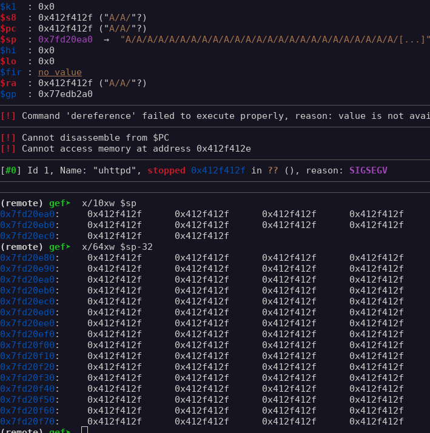

Since we have control of where PC goes, where should we make it go? Well what are our goals and what resources do we have available?

Usually our goal is to have it run our code, more specifically to have it run our code to start a reverse shell or a bind shell - two methods for getting a remote terminal on the target.

Let's look at what we can use

## Ret2LibC

**Lib C** is the standard library for the C programming language. There is a term **Ret2LibC** meaning instead of writing all the shellcode for what we are doing, we can levearge these functions in libc by returning to libc functions. In particular the execute functions are interesting

### system() vs execve()

`system()` and `execve()` are two easy functions to get our remote terminal. We can use them to start a `/bin/sh` with whatever arguments we want for networking.

The function `exec( PATH )` does what you imagine it would, executes the provided argument. There is a family of `exec*()` functions but they are all wrappers around `execve( path, args, environment)` meaning each of the `exec*()` functions are converted to `execve` with different predetermined arguments.

When called `execve( path, args, environment)` will replace the calling program's code (process image) with the code from the new path.

`system(arg)` will create a new child process and start a terminal in that new process while passing the argument to that terminal. Technically it calls `fork()` then is a wrapper on `execl("/bin/sh", "sh", "-c", arg, (char *) NULL)` and then `waitpid()` so the parent process waits until the child exits

We will use `system()` for now because it will save us time, `execve()` is considered more efficient and quieter but makes the exploit code slightly bigger because you have additional arguments and calls to setup. More information on them can be found in the man pages for exec, execve, and system

## Our Goal

We are going to start with the basics. For our **Proof of Concept** (**PoC**), we are going to use some shellcode and

`system(reboot)`

This will be easy to do and verify it is working, later we can build from it.

**Our goal is going to be to write shellcode to get the running program to call `system()` in libc with a pointer (the address) to the string "reboot" in a0, the first argument register.**

# The PoC

## Finding the Offset for the Return Address

Our first step is going to be finding where the return address was in the 200 `A\A\` we sent earlier. We can do this by putting a pattern in and finding which part of the pattern ends up in PC.

gef has a nifty command to create a pattern we can use

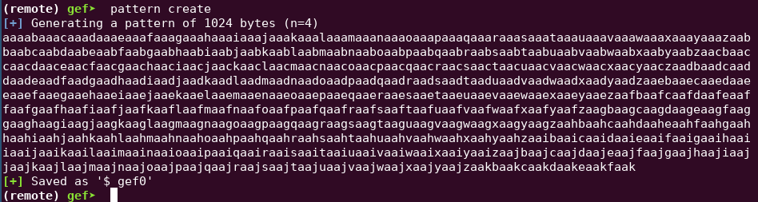

You can modify our exploit template again like this. You do not need to use all of the pattern, I just used the top 3 lines.

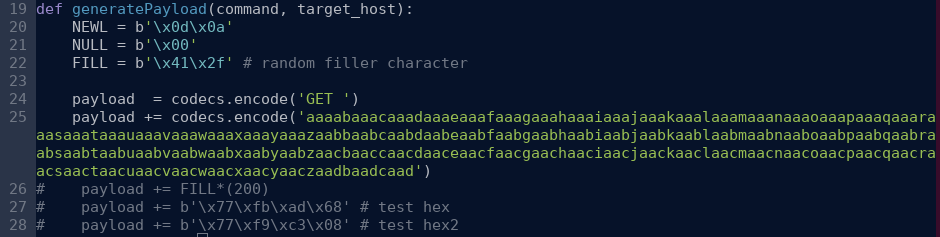

You should need to reconnect gdbserver since uhttpd was crashed, once you are connected and hit continue in the debugger, throw our packet again.

```
./exploit_template.py -i 192.168.100.1
```

You should see something like this

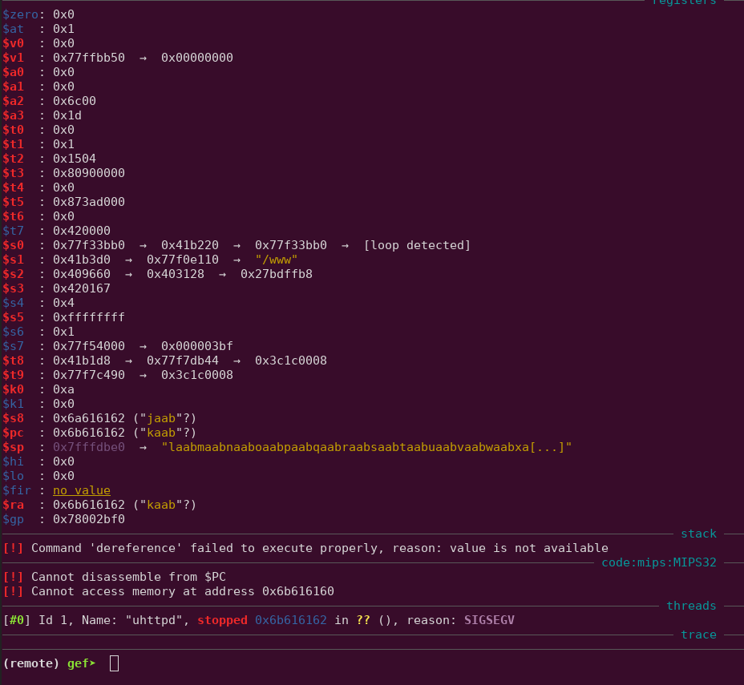

Notice that `$pc` contains "kaab", now we need to find where that is in our pattern. That is where the return address was, and whatever value we put there is where the CPU will try to go.

Also look at `$s8` (frame pointer) and `$sp`

## Returning to the Stack

Once we find "kaab" in our pattern, we need to replace it with a good address for the function to return to. For this exercise we can just return to where the stack pointer points, at `0x7fffdbe0`

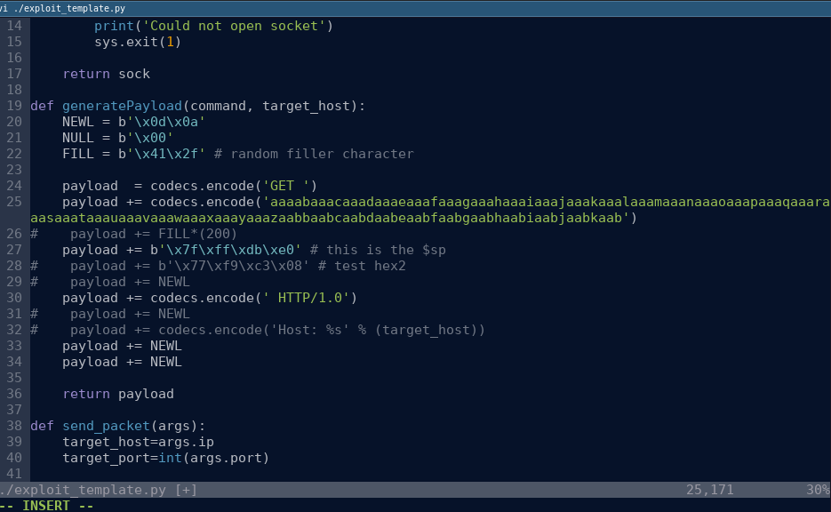

At the end of my string see the `jaabkaab`, a "`laab` should follow `kaab`.

The `jaab` was in `$s8` so we could replace it with a value if we need.

Delete the `kaab` and everything after it in the pattern, then add the hex for our `$sp`. We will use this as our **return address**

Since `$sp` pointed to "laab" anything after this will be **executed by the cpu**

Before we begin writing the actual shellcode, we need the address of `system()` Let's take a moment to pull libc (`/lib/libc.so`) from the target with SCP like we did with uhttpd earlier.

## Looking at Binaries

Now we are going to use a reversing tool on the binaries. Common tools are IDA, Ghidra, Radare2, and Binary Ninja. If you have a favorite already, feel free to use it. However for this course I will be using Ghidra.

Take a moment now to install one if needed

### Setup Ghidra

In ghidra everything has to be done in a project, so once you open it we are going to go to File -> New Project (or the keybind Ctrl + N)

In the popup we are going to follow the prompts, create a Non-Shared Project, and select the location and name

When your are back at the main ghidra window again go to File -> Import File (keybind I) and select libc.so and click ok. The default options will be fine for this course, ghidra tries to identify the language and file type automatically.

Import uhttpd as well.

You should now have both files listed under your project

Double click libc.so to open and analyze it, we are going to click yes to analyze it now and then analyze with the default options

### Ghidra Quality of Life Settings

These aren't mandatory but here are some common settings adjustments

Go to Edit -> Tool Options

**View structure offsets in Hex**  
Edit -> Tool Options -> Editors -> Structure Editor  
Check "Show numbers in hex"

**Display stack and register values instead of labels**  
Edit -> Tool options -> Listing Fields -> Operand Field  
Uncheck Markup Inferred/Stack/Register Variable References

**Increase memory limit OPTIONAL**  
open `/<path to ghidra installation>/ghidra_<version>/ghidraRun` and uncomment the MAXMEM line and specify how many gigabytes of memory to allocate to ghidra  
*this is useful if you are doing more complex projects*

### Finding system

You should see something like this

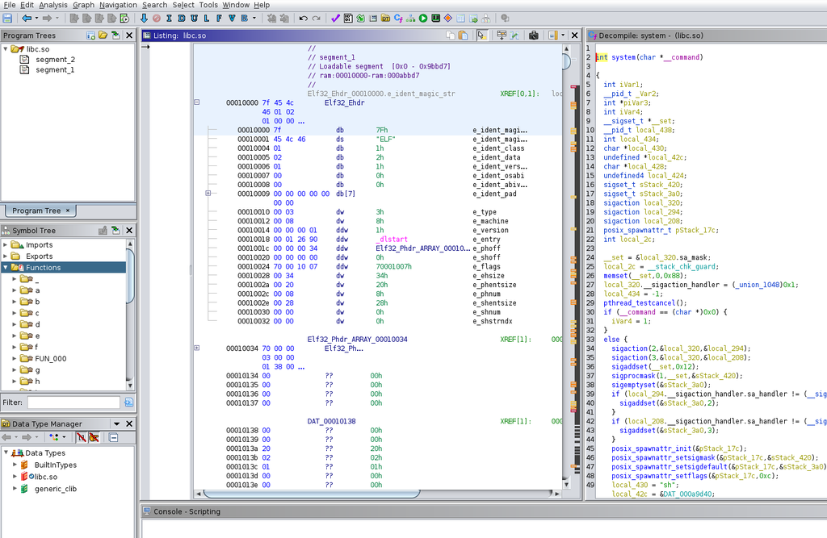

We have some navigation windows on the left, then in center we have our assembly. The first black column is the address, then in blue is the data in hexidecimal and to the right (still in the center) it translates it if it can.

The right window is the decomiler where it tries to provide a C rendering of the assembly. This is not always accurate especially in complex programs. However it can be useful to get a quick idea of whats going on.

To make things easier we are going to start by rebasing the numbers, in the center window it begins at `0x00010000` but if we remember our memory map from before, that is not where `/lib/libc.so` begins

We are going to the circuit board looking button next to the play button at the top, or Window -> Memory Map, then in the new window there will be a house icon on the top right. This will change the starting address so everything will line up. My memory map had the address of the first libc segment at `0x77f4f000`

Now we can use the middle block of the left, the "Symbol Tree", under functions we can find system and it will bring us to the start of the function.

Clicking it will bring us to the start of system, for me that is `0x77fadfc4`

### Strings

Ghidra also allows us to search for strings with the Search option in the top bar. Both a "/bin/sh" and "reboot" can be found in libc.

I do not plan to use them for this example but it is useful to know for CTFs and other situations.

### MIPS Funtion Prologue

Previously we mentioned the stack frame. The function prologue preps the stack frame and notice below that it is setting `$gp` based off of `$t9`.

This implementation is expecting to be called as a jump to `$t9`, then it sets `$gp` off of `$t9` and uses hardcoded offsets to reach other functions. Because of this we need to make sure `$t9` has the value we jump to (system) or it will crash

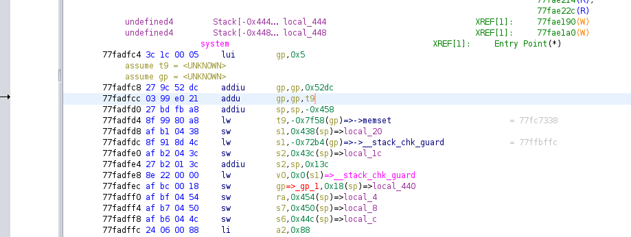

## Building the shellcode

Now we have the address of `system()` but we cannot just return there because we still need to pass it the arguments we want. This is where we make some shellcode.

We need to do the following:  
1 - return to our shellcode on the stack  
2 - set an address in a0 that points to our `reboot` string  
3 - set t9 to the address of system  
4 - adjust stack pointer if needed  
5 - jump to/call system

Think a minute on how to go about this

### Bad Characters

In nearly every exploit there are going to be **bad characters**, or a byte values you cannot use. Usually this is because they are delimiters or end whatever parsing has our overflow in it.

Luckily for us, we only have two bad characters: `0x00` and `0x20`

If we use either of those bytes, the overflow ends. So we need to be sure not to use them inside of our shellcode.

There are many ways to find the bad characters. The simplest is to send an incrementing pattern and see where it ends, then change the byte that ended it and throw again until you have all the bad characters.

### Starting easy

If you recall we know that the "jaab" ends up in `$s8`, so we can put the address of `system()` there. Our code should now look something like this:

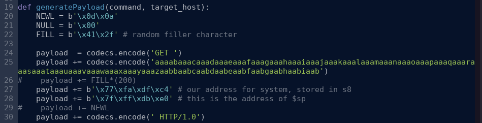

Next let's work on copying that value from `$s8` into `$t9`

MIPS does not have the MOV instruction of x86, but you can use a math or logic instruction with `$s8`, `$t9`, and `zero` (the always zero register) but be careful to check for bad characters in your results

There are several ways to find the opcodes or hex value for an instruction: you can google "MIPS Converter", you can use a code block in ghidra and right click then select patch to modify it, you can write in C and compile for the mips, or you can use pwntools asm in python

**Click here for one solution**

```
I went with "or t9, $s8, zero" which does an OR on s8 and zero and saves the results in t9
The opcodes are "03 c0 c8 25"
```

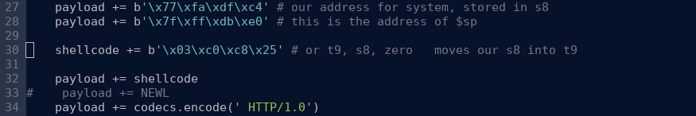

*s8 is also called the frame pointer (fp) and is why it was next to the return address on the stack

### Our Command String

This is where it starts to get tricky. What were those bad characters? A space and the null, which marks the end of the string

The easy solution is to use one of the fixed address strings in libc, but what if you want to change it later? That approach is good for a CTF but less fun

Since we don't care about the end of our HTTP packet, we can just put the string after our shellcode and find its address.

If we want to do a complicated command we will need to find a way around the spaces, and the command will be visible in any packet capture. Those can be addressed later but for now we don't care.

My plan is to put "reboot" after the shellcode and use `addiu $a0, $sp 0xoffset` to get it into the `$a0` register. This will add the offset to the value of `$sp` and save that address in `$a0`, since `$sp` already points to the shellcode it should be easy. Below I am using 0x38 as a placeholder

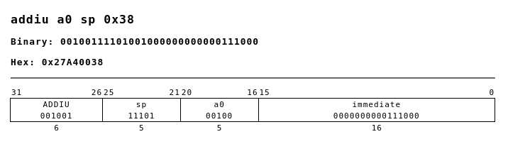

Do you see a problem with this?

**Click here for solution**

```
This will end up as 27 a4 00 38, and as we said earlier the 00 will be a bad character

This 00 is from the size allocated to the offset. We can make the offset bigger, what if we make the offset 138 instead of 38?
```

### Adjusting the Stack Pointer

After our shellcode runs and it calls system or execve. It is generally a good idea to make sure the stack pointer isn't near our string or anything that we want to execute after it. Both system and execve call other functions and there is a good chance if the stack pointer is pointing to our command string, that it will be blown away by the stack frames and local variables

Adjusting the stack pointer will also make offsets much easier for us.

If we use `addiu sp, sp, 0xFEC8` 0xFEC8 is the **two's completment** of 0x138 which means it will be treated as -0x138. This instruction adds -0x138 to the stack pointer and saves it in the stack pointer register

This will allow us to populate the lead byte in the immediate or offset section of the instructions

### Calling System

The last piece of our shellcode is calling or jumping to system(). There are several options, take a look at the jump instructions:  
`j target #jump`

`jr rs #jump register`

`jal target #jump and link, saves PC+4 in ra`

`jalr rs, rd #jump and link register, go to address in rs, save PC+4 in ra`

Find a solution among these and click below to see one solution

**Click here for solution**

```
Now our code should look something like this
```

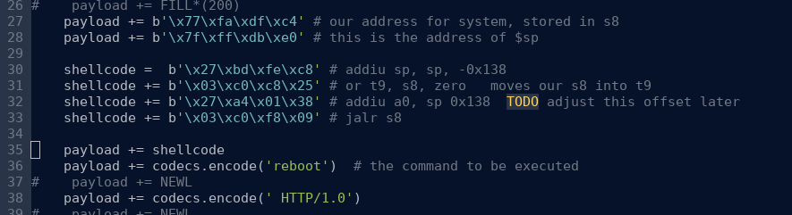

```
I used jalr s8 because if I used t9 we got the 0x20 bad character.
```

### Checking offsets

Now lets setup our debugger, set some breakpoints, and throw it!

Follow the steps from before to setup the debugger, send our exploit, and continue past the **SIGPIPE**

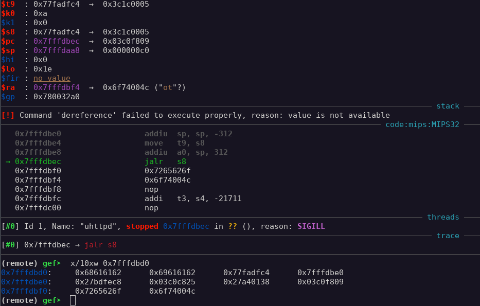

We got a **SIGILL** which means an illegal instruction at our jump, it seems we forgot our **delay slot**. Remember in MIPS after every jump the next instruction will run even if the jump is taken. We need to make sure we have a valid instruction after our jump, any instruction that doesn't change our stuff should be fine.

I'm going to use `lw $s7, 0x138(sp)` with `8f b7 01 38`

While we are here let's also calculate our offset. We need the current sp:

`$sp = 0x7fffdaa8`

Next with `x/10xw 0x7fffdbd0` we can see above that our reboot string starts at `0x7fffdbf0`. I used `0x7fffdbd0` because it is just before our shellcode

The difference is 0x148 but we need to remember we are adding that delay slot, so the new offset we need to use is 0x14c

Updating our offset, it should look like this now:

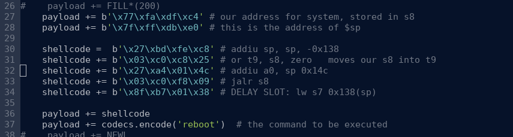

We're going to throw it again, but this time set this breakpoint `b *0x404928` this is the return call before the shellcode. You should also be able to set a breakpoint on the stack value we jump to

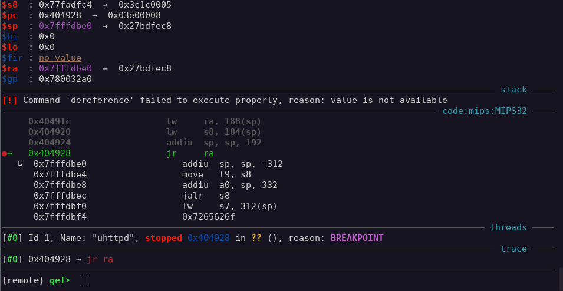

You can step through your shellcode and when you're ready continue

**Be sure to watch the emulation window**

# What's Next?

If you want to keep working on this challenge you can try using execve for something different, then take it a step further and do a reverse shell or bind shell instead of reboot

For a shell you can google pentest reverse shell strings, and use one of those, or you can use shellcode to setup the sockets

Either way **Congratulations** and good luck the next challenge

Hack the Planet!